# Seeing the Forest as well as the Trees - Confirming Forest Measurements from Space

## Project Description

Does low resolution data from space agree with high resolution data from an aerial survey? Can maps from space effectively diagnose forest health? These are questions we explored in this project. Ideally, forest managers could use regional data from satellites to identify areas under stress and then narrow down management plans to smaller plots within that region. Mapping can help prioritize interventions to improve forest health and mitigate water stress reducing the risk of future high-intensity wildfires, especially with the added pressures of climate change. [1]

We compared canopy water content (CWC) derived from high resolution (1 m) data from the National Ecological Observatory Network (NEON) and CWC derived from low resolution (60 m) data from the International Space Station Earth Surface Mineral Dust Source Investigation (EMIT) instrument.[4] to see if there was agreement. We then compared the results from the two with the goal of assessing the resolution required to provide an understanding of forest health.

```python
pip install Pillow
```

```python
from PIL import Image  # image processing library
import os # For dealing with files
from IPython.display import display # Import the display function
import matplotlib.pyplot as plt # Import matplotlib
```

[figure not shown]

```python
# Load image from img folder
image_1 = 'infographic.png'

# Define figure caption
figure_legend = "Figure 1: Co-located NEON and EMIT data over the NEON Soaproot"
"Saddle (SOAP) field site in central California."

# The 'img' folder is directly within the current directory
image_path = os.path.join('img', image_1)

# --- Image Loading and Display ---
try:
    img = Image.open(image_path)

    # Create a matplotlib figure and axes
    fig, ax = plt.subplots(figsize=(11, 6)) # Adjust figsize as needed for your image and text

    # Display the image on the axes
    ax.imshow(img)

    # Hide the axes ticks and labels for a cleaner image display
    ax.axis('off')

    # Add the figure legend with italic font style directly
    plt.figtext(0.5, 0.02, figure_legend,
                ha="center",
                fontsize=12,
                wrap=True,
                fontstyle='italic')

    # Adjust layout to prevent text overlap
    plt.tight_layout(rect=[0, 0.05, 1, 1])

    # Show the plot in the notebook
    plt.show()

except FileNotFoundError:
    print(f"Error: Image not found at {image_path}")
    print("Please ensure your notebook's current working directory is 'exploratory/rn/'.")
except Exception as e:
    print(f"An error occurred: {e}")
```

The small boxes in figure 1 show the area surveyed by the NEON aerial data collection instrument (Airborne Observation Platform, AOP). The larger diamond shows one of the areas surveyed by EMIT from the International Space Station. The SOAP site was chosen as the region of interest because part of the site was burned by a large wildfire in September 2020 and EMIT data also exists for the site. This co-located data allows a comparison between burned and unburned areas in addition to a comparison between different resolutions.

## Project Methods

Both EMIT and NEON hyperspectral instruments passively collect solar radiation in 380 to 426 wavelengths regions. The radiance measurements are then processed into reflectance measurements via a process called atmospheric correction. If you are unfamiliar with Hyperspectral Remote Sensing, refer to this [NEON tutorial](https://www.neonscience.org/resources/learning-hub/tutorials/hyper-spec-intro) before proceeding.

This project began by selecting two 1 km by 1 km areas within the NEON SOAP site for comparison. These areas are called tiles. The chosen tiles can be seen in figure 2; one tile is outlined in green and one is outlined in orange. The green and orange tiles were chosen because they are adjacent to each other and have similar environments, but one tile (orange outline) was burned by the Fall 2020 Creek Fire while the northern tile (green outline) was not. After these two NEON tiles were chosen, a granule from EMIT was identified that covered both of these areas. A granule represents a specific spatiotemporal chunk of data. It's tied to a particular acquisition event (time) and covers a defined 75 km by 75 km geographic area. The EMIT granule was chosen to be close in time of year to aquisition by NEON airborne remote sensing (AOP).

[figure not shown]

```python
# Working directory of the notebook is 'exploratory/rn/'
image_2 = 'burned_area.png'

# Define your desired figure title
figure_title = "SOAP Site Tile Comparison"

# Define your desired figure legend/caption
figure_legend_2 = "Figure 2: Specific tiles within the SOAP site used to compare"
"canopy water content calculations. "

# The 'img' folder is directly within the current directory
image_path = os.path.join('img', image_2)

# --- Image Loading and Display ---
try:
    img = Image.open(image_path)

    # Create a matplotlib figure and axes
    fig, ax = plt.subplots(figsize=(11, 6))

    # Display the image on the axes
    ax.imshow(img)

    # Hide the axes ticks and labels for a cleaner image display
    ax.axis('off')

    # Add the figure legend with italic font style directly
    plt.figtext(0.5, 0.02, figure_legend_2,
                ha="center",
                fontsize=12,
                wrap=True,
                fontstyle='italic')

    # Add the figure title at the top
    ax.set_title(figure_title, fontsize=16, pad=20) # 'pad' adds space between title and image

    # Adjust layout to prevent text overlap
    plt.tight_layout(rect=[0, 0.05, 1, 1]) # Adjust bottom margin to make space for the legend

    # Show the plot in the notebook
    plt.show()

except FileNotFoundError:
    print(f"Error: Image not found at {image_path}")
    print("Please ensure your notebook's current working directory is 'exploratory/rn/'.")
except Exception as e:
    print(f"An error occurred: {e}")
```

The blue squares in figure 2 show the NEON tiles at the SOAP site in and around the Creek Fire boundary (red line). The orange tile is within the burn area and before the fire, had a similar environment to the green tile which was not burned.

## Discussion of Project Findings

We expected to see similarities in the CWC calculations derived from the NEON and EMIT datasets. Specifically, we expected that CWC calculated using the high resolution NEON reflectance data would generally agree with CWC calculated using the low resolution EMIT reflectance data. We expected some differences between the NEON and EMIT CWC values, since the EMIT pixels essentially represent an average of 60 x 60 1 m NEON pixels. We also expected to see that CWC calculated for the burned tile would be lower than CWC calculated for the unburned tile, for both the NEON or EMIT reflectance data sources.

After calculating CWC with NEON and EMIT reflectance data for the burned and unburned tiles and plotting the CWC, visually the plots show general agreement on areas with very high or very low CWC. The different resolutions between EMIT and NEON are also very obvious; the NEON pixels are much smaller and show more detailed CWC measurements.(see figure 3). Also, a visual comparison of the plots shows that the unburned tile CWC calculations are higher than the burned tile CWC calculations, for both NEON and EMIT.

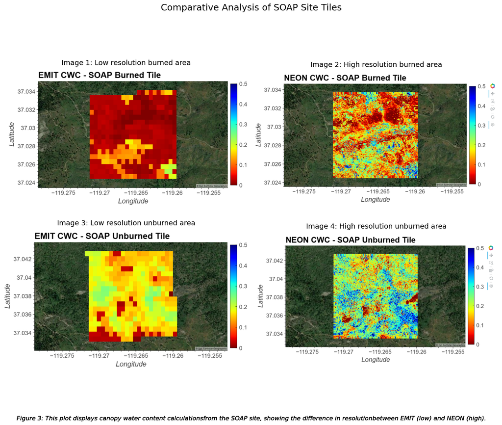

```python
# --- Configuration ---
# Current working directory of the notebook (used for robust pathing)
current_working_directory = os.getcwd()
image_folder = os.path.join(current_working_directory, 'img')

# List of your image filenames
image_filenames = [
    'EMIT_burned.png',
    'NEON_burned.png',
    'EMIT_unburned.png',
    'NEON_unburned.png'
]

# Optional: List of titles for each image (should match the order of image_filenames)
image_titles = [
    "Image 1: Low resolution burned area",
    "Image 2: High resolution burned area",
    "Image 3: Low resolution unburned area",
    "Image 4: High resolution unburned area"
]

# Optional: Main title for the entire figure
main_figure_title = "Comparative Analysis of SOAP Site Tiles"

# Overall legend/caption for the entire figure
main_figure_legend = (
    "Figure 3: This plot displays canopy water content calculations"
    "from the SOAP site, showing the difference in resolution"
    "between EMIT (low) and NEON (high)."
)

# --- Create the plot grid ---
# Create a figure and a 2x2 grid of subplots
# We unpack the 'axs' into a 2D array: axs[row, col]
fig, axs = plt.subplots(2, 2, figsize=(14, 12)) # Example figsize, adjust as needed

# --- Load and display each image ---
for i, filename in enumerate(image_filenames):
    image_path = os.path.join(image_folder, filename)

    # Determine the subplot position (row, col) in a 2x2 grid
    row = i // 2 # Integer division for row: 0, 0, 1, 1
    col = i % 2  # Modulo for column: 0, 1, 0, 1

    try:
        img = Image.open(image_path)

        # Display the image in the current subplot
        axs[row, col].imshow(img)

        # Hide axes ticks and labels for a cleaner image display
        axs[row, col].axis('off')

        # Add the figure legend with italic font style directly
        plt.figtext(0.5, 0.02, main_figure_legend,
                ha="center",
                fontsize=12,
                wrap=True,
                fontstyle='italic')

        # Add a title to each subplot
        if i < len(image_titles): # Check if a title exists for this image
            axs[row, col].set_title(image_titles[i], fontsize=14, pad=10)

    except FileNotFoundError:
        print(f"Error: Image not found for '{filename}' at {image_path}")
        axs[row, col].set_title(f"Image not found: {filename}")
        axs[row, col].axis('off') # Still hide axes if error
    except Exception as e:
        print(f"An error occurred loading '{filename}': {e}")
        axs[row, col].set_title(f"Error: {filename}")
        axs[row, col].axis('off')

# --- Add overall figure elements (title and legend) ---

# Add a main title for the entire figure
fig.suptitle(main_figure_title, fontsize=18, y=0.98) # 'y' adjusts vertical position

# Adjust layout to prevent text/image overlap
# rect=[left, bottom, right, top] - values are normalized from 0 to 1
plt.tight_layout(rect=[0, 0.06, 1, 0.94]) # Adjust bottom and top margins

# Show the combined plot in the notebook
plt.show()
```

## References

1. Le, T. S., Dell, B., & Harper, R. (2025). Remote-Sensed Evidence of Fire Alleviating Forest Canopy Water Stress Under a Drying Climate. Remote Sensing, 17(12). https://doi.org/https://doi.org/10.3390/rs17121979
2. Soaproot Saddle NEON | NSF NEON | Open Data to Understand our Ecosystems. (n.d.). Retrieved April 27, 2025 from https://www.neonscience.org/field-sites/soap
3. Randolph, K., Morin, R., Dooley, K., Nelson, M. D., Jovan, S., Woodall, C. W., Schulz, B. K., Perry, C. H. (Hobie), Kurtz, C., Oswalt, S., McWilliams, W., & Riemann, R. (2020). Forest Ecosystem Health Indicators. Forest Service U.S. Department of Agriculture. https://research.fs.usda.gov/understory/forest-ecosystem-health-indicators
4. Green, R. (2023). EMIT L2B Estimated Mineral Identification and Band Depth and Uncertainty 60 m V001. NASA Land Processes Distributed Active Archive Center. https://doi.org/10.5067/EMIT/EMITL2BMIN.001
5. Bohn, N., Guanter, L., Kuester, T., Preusker, R., & Segl, K. (2020). Coupled retrieval of the three phases of water from spaceborne imaging spectroscopy measurements. Remote Sensing of Environment, 242. https://doi.org/https://doi.org/10.1016/j.rse.2020.111708